# Ngā Rourou Raraunga - Hack Aotearoa 2020

Alessandra

18/01/2020

## Introducing MIMIC-III

"MIMIC-III (Medical Information Mart for Intensive Care III) is a large, freely-available database comprising deidentified health-related data associated with over forty thousand patients who stayed in critical care units of the Beth Israel Deaconess Medical Center between 2001 and 2012.

The database includes information such as demographics, vital sign measurements made at the bedside (~1 data point per hour), laboratory test results, procedures, medications, caregiver notes, imaging reports, and mortality (both in and out of hospital).

MIMIC supports a diverse range of analytic studies spanning epidemiology, clinical decision-rule improvement, and electronic tool development. It is notable for three factors:

it is freely available to researchers worldwide it encompasses a diverse and very large population of ICU patients it contains high temporal resolution data including lab results, electronic documentation, and bedside monitor trends and waveforms."

Source: https://mimic.physionet.org/about/mimic/

## The problem

Hospitals have fewer staff on site ‘out of hours’ for cost and morale reasons.

## Hypothesis

Could the healthcare be impact by ‘out of hours’ factor indicating less/worse care, thus resulting in a higher hospital mortality?

To the best of our knowledge, this hypothesis has never been quantified before.

## Step 1

Assess the policies efficiency by using reinforcement learning and correlating hospital mortality and in/out of hours care.

Disclaimer: reaaally complex approach, multiple times advised by the mentors, therefore, we’ve work in parallel in a step 2.

## Step 2

Less complex approaches to assess possible correlation between hospital mortality and in/out of hours care, such as exploratory and regressions analyses.

## Loading R packages

```r
if (!require("pacman")) install.packages("pacman")
pacman::p_load("tidyverse","viridis", "tableone", "stargazer")
```

## Loading data

```r
MIMICtable = read_csv("MIMICtable.csv")
```

## Data summary

```r
factor_vars = c("gender", "mechvent", "sedation")
num_vars = c("age", "Weight_kg", "GCS", "HR", "SysBP", "MeanBP", "DiaBP","RR","Temp_C",
             "Glucose","WBC_count","Platelets_count","SOFA","SIRS")

table_one = CreateTableOne(vars = num_vars, strata = "died_in_hosp", data = MIMICtable, factorVars = factor_vars)

table_one$ContTable
```

```
##                              Stratified by died_in_hosp
##                               0                  1                  p      test
##   n                           830070             154199
##   age (mean (SD))             23287.72 (6099.07) 25029.58 (5660.80) <0.001
##   Weight_kg (mean (SD))          83.18 (25.00)      80.21 (23.49)   <0.001
##   GCS (mean (SD))                13.00 (3.09)       10.84 (4.17)    <0.001
##   HR (mean (SD))                 86.30 (16.94)      91.05 (19.17)   <0.001
##   SysBP (mean (SD))             119.88 (21.33)     114.25 (21.85)   <0.001
##   MeanBP (mean (SD))             78.47 (14.66)      75.07 (15.03)   <0.001
##   DiaBP (mean (SD))              56.85 (14.15)      54.31 (14.26)   <0.001
##   RR (mean (SD))                 19.98 (5.54)       21.62 (6.31)    <0.001
##   Temp_C (mean (SD))             36.89 (0.99)       36.77 (1.18)    <0.001
##   Glucose (mean (SD))           138.22 (50.87)     145.84 (56.31)   <0.001
##   WBC_count (mean (SD))          12.05 (7.58)       14.03 (10.66)   <0.001
##   Platelets_count (mean (SD))   234.11 (137.97)    198.20 (140.91)  <0.001
##   SOFA (mean (SD))                6.70 (3.18)        9.81 (4.05)    <0.001
##   SIRS (mean (SD))                1.57 (1.04)        2.04 (1.02)    <0.001
```

```r
table_one$CatTable
```

## Exploratory analyses

### SOFA score

#### SOFA score equal or above 9 - Hourly

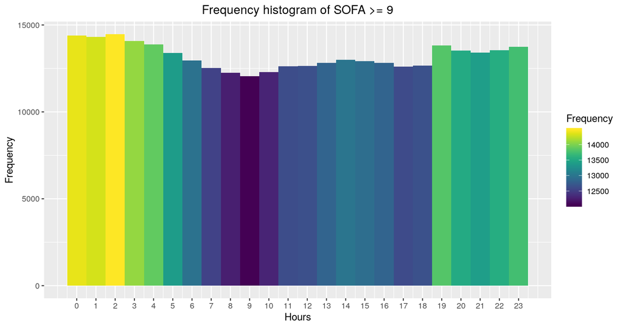

```r
ggplot(MIMICtable %>% filter(SOFA >= 9), aes(x = timeday)) + geom_histogram(aes(fill = ..count..), binwidth = 1) + ggtitle("Frequency histogram of SOFA >= 9") + theme(plot.title = element_text(hjust = 0.5)) + xlab("Hours") + ylab("Frequency") + labs(fill="Frequency") + scale_x_continuous(breaks = seq(0, 23, by = 1)) + scale_fill_viridis()
```

#### All SOFA score frequencies - Hourly

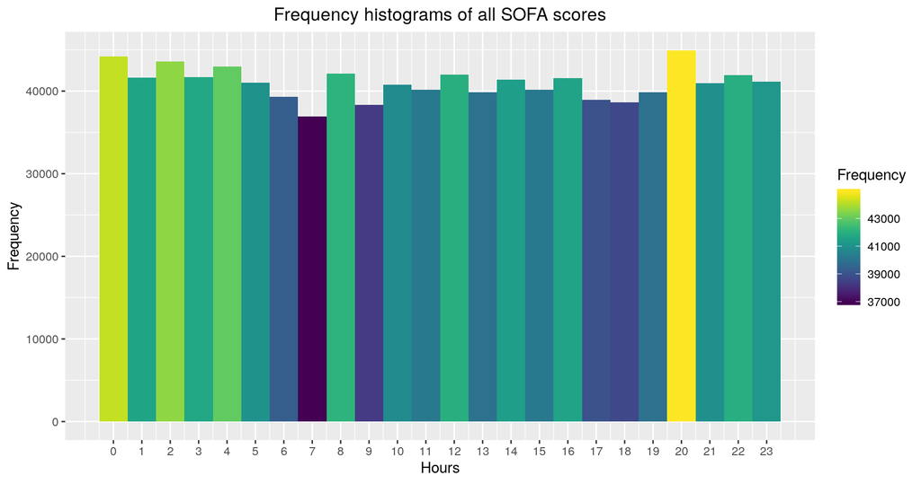

```r
ggplot(MIMICtable, aes(x = timeday)) + geom_histogram(aes(fill = ..count..), binwidth = 1) + ggtitle("Frequency histograms of all SOFA scores") + theme(plot.title = element_text(hjust = 0.5)) + xlab("Hours") + ylab("Frequency") + labs(fill="Frequency") + scale_x_continuous(breaks = seq(0, 23, by = 1)) + scale_fill_viridis()
```

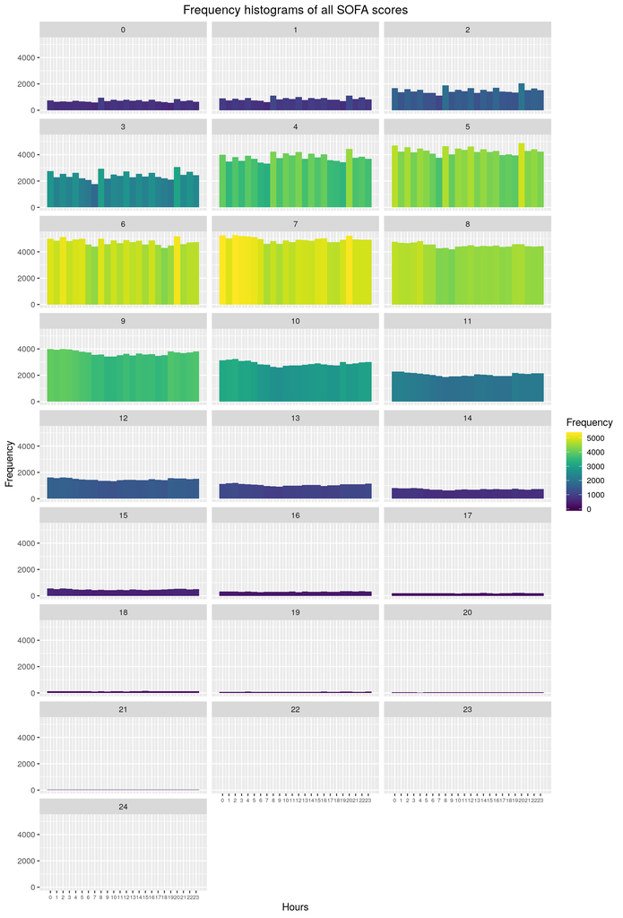

```r
ggplot(MIMICtable, aes(x = timeday)) + geom_histogram(aes(fill = ..count..), binwidth = 1) + ggtitle("Frequency histograms of all SOFA scores") + theme(plot.title = element_text(hjust = 0.5), axis.text.x = element_text(size = 6)) + xlab("Hours") + ylab("Frequency") + labs(fill="Frequency") + scale_x_continuous(breaks = seq(0, 23, by = 1)) + scale_fill_viridis() + facet_wrap(~SOFA, ncol = 3)
```

#### All SOFA score differences frequencies - Hourly

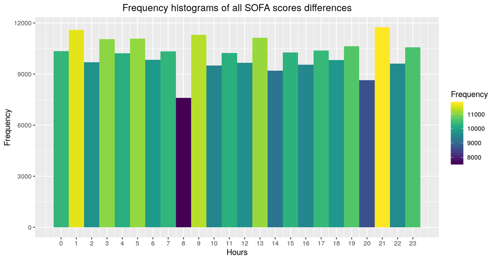

```r
MIMICtable_sofa_diff = na.omit(MIMICtable %>%
  group_by(icustayid) %>%
  mutate(Diff = SOFA - lag(SOFA)) %>%
  filter(Diff > 0))

ggplot(MIMICtable_sofa_diff, aes(x = timeday)) + geom_histogram(aes(fill = ..count..), binwidth = 1) + ggtitle("Frequency histograms of all SOFA scores differences") + theme(plot.title = element_text(hjust = 0.5)) + xlab("Hours") + ylab("Frequency") + labs(fill="Frequency") + scale_x_continuous(breaks = seq(0, 23, by = 1)) + scale_fill_viridis()
```

### Mortality days

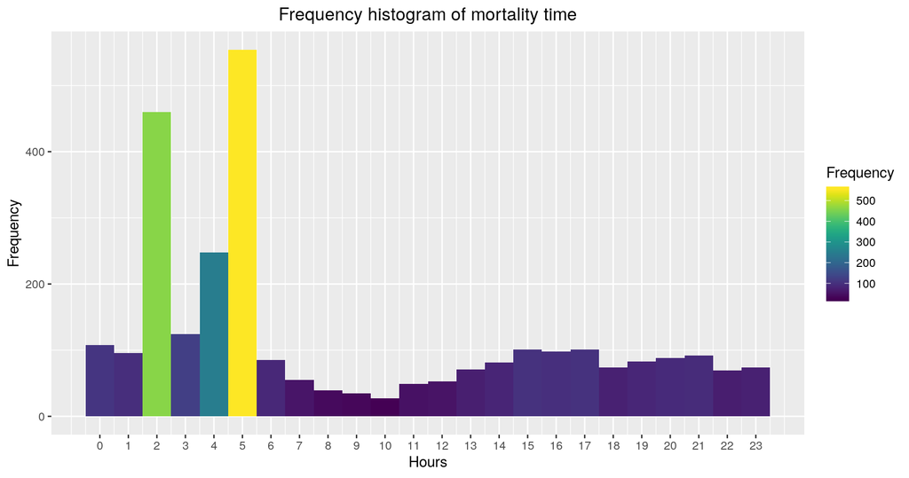

```r
MIMICtable_time_death = MIMICtable %>%
  filter(died_in_hosp == 1) %>%
  group_by(icustayid) %>%
  slice(which.max(bloc))

ggplot(MIMICtable_time_death, aes(x = timeday)) + geom_histogram(aes(fill = ..count..), binwidth = 1) + ggtitle("Frequency histogram of mortality time") + theme(plot.title = element_text(hjust = 0.5)) + xlab("Hours") + ylab("Frequency") + labs(fill="Frequency") + scale_x_continuous(breaks = seq(0, 23, by = 1)) + scale_fill_viridis()
```

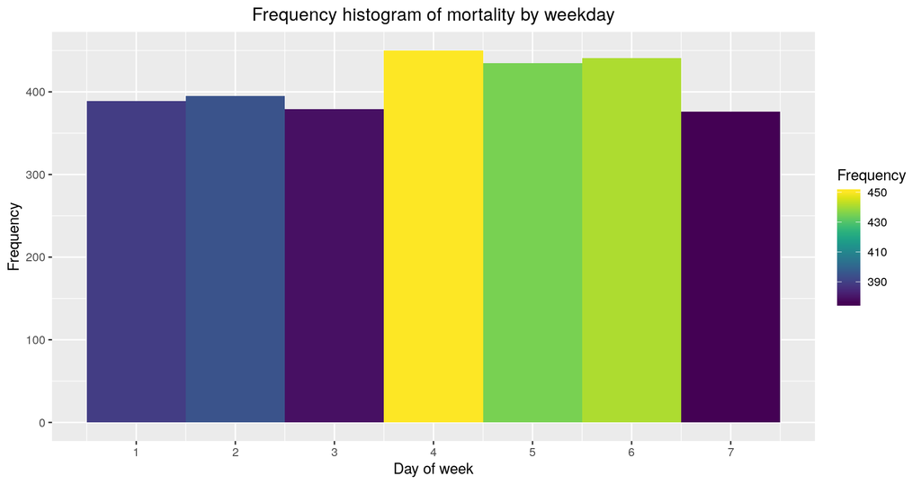

```r
ggplot(MIMICtable_time_death, aes(x = dayweek)) + geom_histogram(aes(fill = ..count..), binwidth = 1) + ggtitle("Frequency histogram of mortality by weekday") + theme(plot.title = element_text(hjust = 0.5)) + xlab("Day of week") + ylab("Frequency") + labs(fill="Frequency") + scale_x_continuous(breaks = seq(0, 7, by = 1)) + scale_fill_viridis()
```

### Diversity

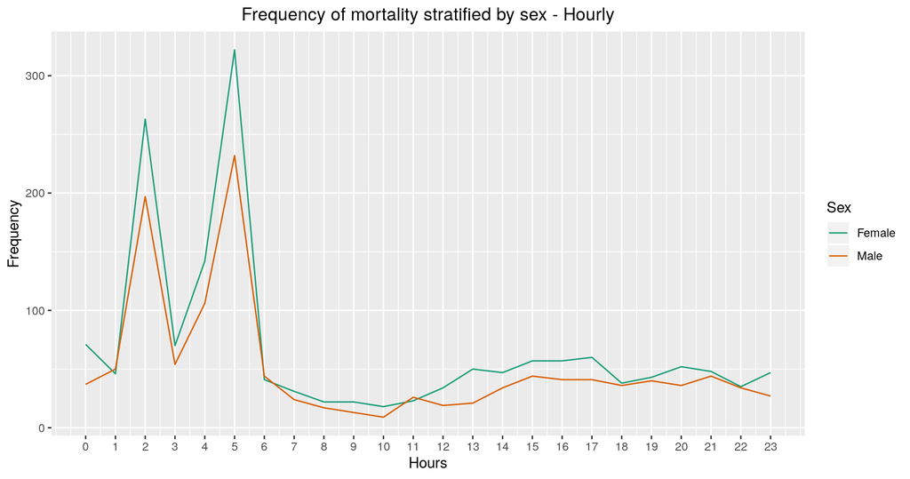

```r
# MIMICtable_diversity = MIMICtable %>%
#   filter(died_in_hosp == 1) %>%
#   group_by(timeday, gender) %>%
#   summarise(count = n())

MIMICtable_diversity = MIMICtable_time_death %>%
  group_by(timeday, gender) %>%
  summarise(count = n())

ggplot(MIMICtable_diversity, aes(x = timeday, y = count, color = as.factor(gender))) + geom_line() + ggtitle("Frequency of mortality stratified by sex - Hourly") + theme(plot.title = element_text(hjust = 0.5)) + xlab("Hours") + ylab("Frequency") + labs(color="Sex") + scale_x_continuous(breaks = seq(0, 23, by = 1)) + scale_color_brewer(labels = c("Female", "Male"), palette = "Dark2")
```

## Regression analyses

### Mortality association with hour of the day

```r
MIMICtable$timeday_factor = as.factor(MIMICtable$timeday)
glm_died_hosp = glm(died_in_hosp ~ timeday_factor, data = MIMICtable, family = "binomial")
#summary(glm_died_hosp)
stargazer(glm_died_hosp, align=TRUE, type = "html", style = "all")
```

|  | *Dependent variable:* |
| --- | --- |
|  | died_in_hosp |
| timeday_factor1 | -0.010 |
|  | (0.019) |
|  | t = -0.531 |
|  | p = 0.596 |
| timeday_factor2 | -0.021 |
|  | (0.018) |
|  | t = -1.125 |
|  | p = 0.261 |
| timeday_factor3 | -0.037** |
|  | (0.019) |
|  | t = -1.987 |
|  | p = 0.047 |
| timeday_factor4 | -0.050*** |
|  | (0.019) |
|  | t = -2.705 |
|  | p = 0.007 |
| timeday_factor5 | -0.080*** |
|  | (0.019) |
|  | t = -4.228 |
|  | p = 0.00003 |
| timeday_factor6 | -0.093*** |
|  | (0.019) |
|  | t = -4.874 |
|  | p = 0.00001 |
| timeday_factor7 | -0.099*** |
|  | (0.019) |
|  | t = -5.098 |
|  | p = 0.00000 |
| timeday_factor8 | -0.067*** |

[output cut: 73 more lines]

### Mortality association with interaction of hour of the day and SOFA score

```r
glm_died_hosp_sofa = glm(died_in_hosp ~ timeday_factor * SOFA, data = MIMICtable, family = "binomial")
#summary(glm_died_hosp_sofa)
stargazer(glm_died_hosp_sofa, align=TRUE, type = "html", style = "all")
```

|  | *Dependent variable:* |
| --- | --- |
|  | died_in_hosp |
| timeday_factor1 | -0.050 |
|  | (0.055) |
|  | t = -0.899 |
|  | p = 0.369 |
| timeday_factor2 | -0.039 |
|  | (0.054) |
|  | t = -0.722 |
|  | p = 0.471 |
| timeday_factor3 | -0.043 |
|  | (0.055) |
|  | t = -0.780 |
|  | p = 0.436 |
| timeday_factor4 | -0.054 |
|  | (0.055) |
|  | t = -0.995 |
|  | p = 0.320 |
| timeday_factor5 | -0.116** |
|  | (0.056) |
|  | t = -2.068 |
|  | p = 0.039 |
| timeday_factor6 | -0.179*** |
|  | (0.057) |
|  | t = -3.132 |
|  | p = 0.002 |
| timeday_factor7 | -0.188*** |
|  | (0.058) |
|  | t = -3.212 |
|  | p = 0.002 |
| timeday_factor8 | -0.014 |

[output cut: 169 more lines]

### SOFA score associated with the interaction of mortality and hour of the day

```r
glm_sofa = glm(SOFA ~ timeday_factor * died_in_hosp, data = MIMICtable, family = "gaussian")
#summary(glm_sofa)
stargazer(glm_sofa, align=TRUE, type = "html", style = "all")
```

|  | *Dependent variable:* |
| --- | --- |
|  | SOFA |
| timeday_factor1 | 0.198*** |
|  | (0.025) |
|  | t = 7.984 |
|  | p = 0.000 |
| timeday_factor2 | 0.082*** |
|  | (0.025) |
|  | t = 3.327 |
|  | p = 0.001 |
| timeday_factor3 | 0.174*** |
|  | (0.025) |
|  | t = 7.016 |
|  | p = 0.000 |
| timeday_factor4 | 0.025 |
|  | (0.025) |
|  | t = 1.021 |
|  | p = 0.308 |
| timeday_factor5 | 0.109*** |
|  | (0.025) |
|  | t = 4.376 |
|  | p = 0.00002 |
| timeday_factor6 | 0.138*** |
|  | (0.025) |
|  | t = 5.499 |
|  | p = 0.00000 |
| timeday_factor7 | 0.232*** |
|  | (0.026) |
|  | t = 9.086 |
|  | p = 0.000 |
| timeday_factor8 | -0.325*** |

[output cut: 169 more lines]